# Practical Machine Learning

Bastian Huntgeburth

27 Januar 2019

# Coursera “Practical Machine Learning project using the Weight Lifting Exercises Dataset

## Executive Summary

Using a dataset, provided by HAR http://groupware.les.inf.puc-rio.br/har , we will train several models to predict different exercises that were recorded by an activity tracker.

For that, several tasks were done:  
- Loading and cleaning the data  
- Split the data in a training and a testing set  
- Training several models using the caret package  
- Choosing a model to predict the outcome for the final quiz

## Loading an Cleaning the data

After loading some library’s, I load the given data for model training and the data for prediction.

```r
library(caret)  # package for Classification and Regression Training
library(rattle) # package for a fancy visualisation of a decision tree
library(doSNOW) # package for ditribute the compute load for model-training over several CPU cores
# loading the data an define strings that are interpreted as NA's
dataset <- read.csv(file="D:/Coursera/RWorkingDirectory/pml-training.csv", na.strings=c("NA","#DIV/0!",""), row.names = "X")
prediction_data <- read.csv(file="D:/Coursera/RWorkingDirectory/pml-testing.csv", na.strings=c("NA","#DIV/0!",""), row.names = "X")
```

Now we take a look at the data quality. We calculate the percentage of NAs per column and show the result in a histogram.

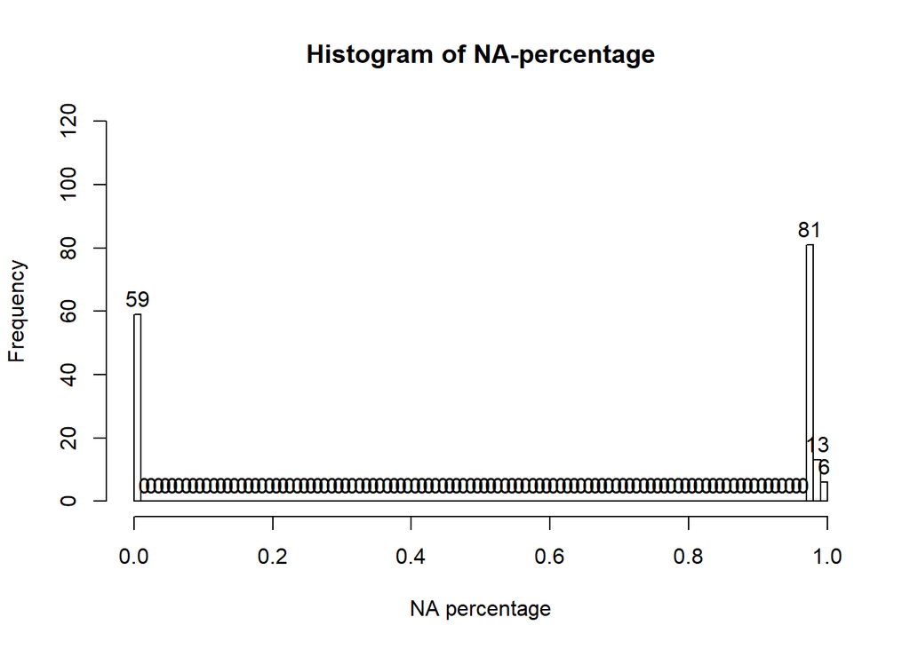

```r
# create a vector to save the perentage of NAs of a column
col_na_p<-c(rep(0,dim(dataset)[[2]]))

# calculate the percentage of NAs of a column
for(i in 1:dim(dataset)[[2]]){
        col_na_p[i]<-sum(is.na(dataset[,i]))/dim(dataset)[[1]]
}

# create a hostogram of the percentage of the NAs per column
hist(col_na_p, labels = T, main= "Histogram of NA-percentage", ylim = c(0,120), xlab = "NA percentage", breaks = 100)
```

```r
# remove columns where NA-percentage is above 50%
dataset<-dataset[,col_na_p<0.5]
```

We can see, that there are 100 features which have a NA-percentage of near 100%. Although we have 59 features where the NA percentage is zero (actually this includes the class-feature which is our training label). We assume that the information of the feature, with a high NA-percentage, is really low.

As a result we remove all features with a NA-percentage above 50%.

In a next step we check if there are features with near-zero variance. These features will not have any knowledge that can be used in a prediction model.

```r
nzv<-nearZeroVar(dataset,saveMetrics=TRUE)     # calculate the variance of each feature
sum_nzv<-sum(nzv$nzv)    # sum up the number of feature with near zero variance
sum_nzv
```

```
## [1] 1
```

```r
dataset<-dataset[,nzv$nzv==F]   # remove the features with near zero variance from the dataset
```

We have 1 feature with near zero variance, which was also removed from the dataset.

## Spliting the dataset and training models

Now we split the dataset in a labeled training and testing set. The 60%/40% split should be appropriate for a medium sized dataset.

```r
set.seed(12345)         # set seed for reproducibility
inTrain <- createDataPartition(dataset$classe, p=0.6, list=FALSE)      # split the dataset in train- and testing data
myTraining <- dataset[inTrain, ]
myTesting <- dataset[-inTrain, ]
dim_train<-dim(myTraining)
dim_test<-dim(myTesting)
```

Now we have 11776 observations in out training set and 7846 observations in our testset.

In the next steps we will build several model based on the training dataset. We will use a k-fold cross-validation, with k=10, which would be a good balance between smaller bias and higher variance.

First we will train a simple decision tree. We set the “tuneLenght” parameter to get several trees with different depths to choose the tree with the highest accuracy.

```r
set.seed(112233)

# create doSNOW Cluster
cl<-makeCluster(16, type = "SOCK")
registerDoSNOW(cl)

# Train a simple decision tree
train_control_rpart<-trainControl(method="cv", number=10)
fit_rpart <- train(classe ~ ., method="rpart2", data=myTraining, trControl=train_control_rpart, tuneLength = 10)
fit_rpart                               # print the model details
```

```
## CART
##
## 11776 samples
##    57 predictor
##     5 classes: 'A', 'B', 'C', 'D', 'E'
##
## No pre-processing
## Resampling: Cross-Validated (10 fold)
## Summary of sample sizes: 10598, 10598, 10599, 10598, 10597, 10600, ...
## Resampling results across tuning parameters:
##
##   maxdepth  Accuracy   Kappa
##    1        0.3659999  0.1244203
##    4        0.4867599  0.3389409
##    5        0.5100241  0.3808528
##    7        0.5583349  0.4430624
##   12        0.7043913  0.6257549
##   16        0.7477846  0.6805890
##   17        0.7947477  0.7396985
##   18        0.8081647  0.7568153
##   19        0.8156362  0.7663054
##   20        0.9004695  0.8743284
##
## Accuracy was used to select the optimal model using the largest value.
## The final value used for the model was maxdepth = 20.
```

[figure not shown]

```r
fancyRpartPlot(fit_rpart$finalModel)    # print the decision tree
```

Let’s create a confusion matrix with the remaining testing dataset.

```r
prediction_rpart <- predict(fit_rpart, myTesting)       # predict the outcome of the testing dataset
cmrf_rpart <- confusionMatrix(prediction_rpart, myTesting$classe)       # create the confusion matrix
cmrf_rpart
```

```
## Confusion Matrix and Statistics
##
##           Reference
## Prediction    A    B    C    D    E
##          A 2024   41    3   25   17
##          B   69 1391   29    0    0
##          C   51   23 1224   28   27
##          D   70   55  101 1224  142
##          E   18    8   11    9 1256
##
## Overall Statistics
##
##                Accuracy : 0.9073
##                  95% CI : (0.9007, 0.9137)
##     No Information Rate : 0.2845
##     P-Value [Acc > NIR] : < 2.2e-16
##
##                   Kappa : 0.8831
##  Mcnemar's Test P-Value : < 2.2e-16
##
## Statistics by Class:
##
##                      Class: A Class: B Class: C Class: D Class: E
## Sensitivity            0.9068   0.9163   0.8947   0.9518   0.8710
## Specificity            0.9847   0.9845   0.9801   0.9439   0.9928
## Pos Pred Value         0.9592   0.9342   0.9047   0.7688   0.9647
## Neg Pred Value         0.9637   0.9800   0.9778   0.9901   0.9716
## Prevalence             0.2845   0.1935   0.1744   0.1639   0.1838
## Detection Rate         0.2580   0.1773   0.1560   0.1560   0.1601
## Detection Prevalence   0.2689   0.1898   0.1724   0.2029   0.1659
## Balanced Accuracy      0.9457   0.9504   0.9374   0.9478   0.9319
```

We see that the accuracy of our first model is 90%.

Next we train a random forest model.

```r
# Train the random forest
train_control_rf <- trainControl(method="cv", number=10)
fit_rf <- train(classe ~ ., method="rf", data=myTraining, trControl=train_control_rf)
fit_rf          # print the model details
```

```
## Random Forest
##
## 11776 samples
##    57 predictor
##     5 classes: 'A', 'B', 'C', 'D', 'E'
##
## No pre-processing
## Resampling: Cross-Validated (10 fold)
## Summary of sample sizes: 10598, 10599, 10598, 10598, 10598, 10597, ...
## Resampling results across tuning parameters:
##
##   mtry  Accuracy   Kappa
##    2    0.9870923  0.9836703
##   40    0.9988959  0.9986035
##   79    0.9986417  0.9982820
##
## Accuracy was used to select the optimal model using the largest value.
## The final value used for the model was mtry = 40.
```

Let’s create a confusion matrix for this model with the remaining testing dataset.

```r
prediction_rf <- predict(fit_rf, myTesting)              # predict the outcome of the testing dataset
cmrf_rf <- confusionMatrix(prediction_rf, myTesting$classe)     # create the confusion matrix
cmrf_rf
```

```
## Confusion Matrix and Statistics
##
##           Reference
## Prediction    A    B    C    D    E
##          A 2232    1    0    0    0
##          B    0 1517    1    0    0
##          C    0    0 1367    3    0
##          D    0    0    0 1282    0
##          E    0    0    0    1 1442
##
## Overall Statistics
##
##                Accuracy : 0.9992
##                  95% CI : (0.9983, 0.9997)
##     No Information Rate : 0.2845
##     P-Value [Acc > NIR] : < 2.2e-16
##
##                   Kappa : 0.999
##  Mcnemar's Test P-Value : NA
##
## Statistics by Class:
##
##                      Class: A Class: B Class: C Class: D Class: E
## Sensitivity            1.0000   0.9993   0.9993   0.9969   1.0000
## Specificity            0.9998   0.9998   0.9995   1.0000   0.9998
## Pos Pred Value         0.9996   0.9993   0.9978   1.0000   0.9993
## Neg Pred Value         1.0000   0.9998   0.9998   0.9994   1.0000
## Prevalence             0.2845   0.1935   0.1744   0.1639   0.1838
## Detection Rate         0.2845   0.1933   0.1742   0.1634   0.1838
## Detection Prevalence   0.2846   0.1935   0.1746   0.1634   0.1839
## Balanced Accuracy      0.9999   0.9996   0.9994   0.9984   0.9999
```

We see that the accuracy of our random forest model is 99.9%.

Next we train a gradient boosting model.

```r
# Train a gradient boosting model
train_control_gbm <- trainControl(method = "cv", number = 10)
fit_gbm <- train(classe ~ ., data=myTraining, method = "gbm", trControl = train_control_gbm, verbose = FALSE)
fit_gbm                         # print the model details
```

```
## Stochastic Gradient Boosting
##
## 11776 samples
##    57 predictor
##     5 classes: 'A', 'B', 'C', 'D', 'E'
##
## No pre-processing
## Resampling: Cross-Validated (10 fold)
## Summary of sample sizes: 10599, 10597, 10599, 10598, 10599, 10600, ...
## Resampling results across tuning parameters:
##
##   interaction.depth  n.trees  Accuracy   Kappa
##   1                   50      0.8358495  0.7916484
##   1                  100      0.8968231  0.8693189
##   1                  150      0.9274784  0.9081254
##   2                   50      0.9579653  0.9467847
##   2                  100      0.9872605  0.9838860
##   2                  150      0.9920163  0.9899016
##   3                   50      0.9841201  0.9799094
##   3                  100      0.9934602  0.9917282
##   3                  150      0.9958384  0.9947364
##
## Tuning parameter 'shrinkage' was held constant at a value of 0.1
##
## Tuning parameter 'n.minobsinnode' was held constant at a value of 10
## Accuracy was used to select the optimal model using the largest value.
## The final values used for the model were n.trees = 150,
##  interaction.depth = 3, shrinkage = 0.1 and n.minobsinnode = 10.
```

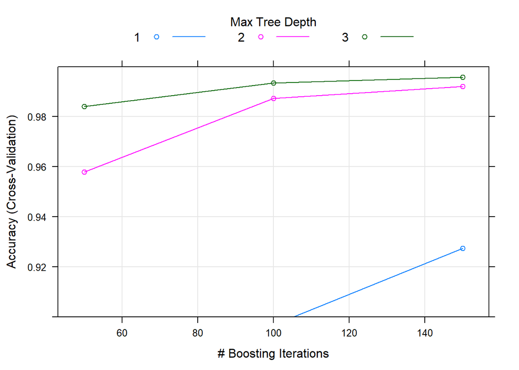

```r
plot(fit_gbm, ylim=c(0.9, 1))   # plot the accuracy function
```

```r
stopCluster(cl)
```

We can see that a tree depth of 3 and a number of 150 trees produces the best accuracy.

Let’s create a confusion matrix for this model with the remaining testing dataset.

```r
prediction_gbm <- predict(fit_gbm, myTesting)             # predict the outcome of the testing dataset
cmrf_gbm <- confusionMatrix(prediction_gbm, myTesting$classe)   # create the confusion matrix
cmrf_gbm
```

```
## Confusion Matrix and Statistics
##
##           Reference
## Prediction    A    B    C    D    E
##          A 2231    4    0    0    0
##          B    1 1512    1    0    0
##          C    0    2 1360   11    0
##          D    0    0    7 1266    1
##          E    0    0    0    9 1441
##
## Overall Statistics
##
##                Accuracy : 0.9954
##                  95% CI : (0.9937, 0.9968)
##     No Information Rate : 0.2845
##     P-Value [Acc > NIR] : < 2.2e-16
##
##                   Kappa : 0.9942
##  Mcnemar's Test P-Value : NA
##
## Statistics by Class:
##
##                      Class: A Class: B Class: C Class: D Class: E
## Sensitivity            0.9996   0.9960   0.9942   0.9844   0.9993
## Specificity            0.9993   0.9997   0.9980   0.9988   0.9986
## Pos Pred Value         0.9982   0.9987   0.9905   0.9937   0.9938
## Neg Pred Value         0.9998   0.9991   0.9988   0.9970   0.9998
## Prevalence             0.2845   0.1935   0.1744   0.1639   0.1838
## Detection Rate         0.2843   0.1927   0.1733   0.1614   0.1837
## Detection Prevalence   0.2849   0.1930   0.1750   0.1624   0.1848
## Balanced Accuracy      0.9994   0.9979   0.9961   0.9916   0.9990
```

# Coosing a model

Since the random forest model has the best accuracy I choose this model for predicting the outcome for quiz dataset. I expect a out of sample error 100%-99.9%=0.1%.

# Prediction of the quiz data

The random forest model predicts the following outcome for the quiz data.

```r
pred_fit_rf <- predict(fit_rf, prediction_data)
pred_fit_rf
```

```
##  [1] B A B A A E D B A A B C B A E E A B B B
## Levels: A B C D E
```